# Amruta Mahendra Parulekar 20d070009 - Speech Processing Assignment 1

# Question 1

Given:

$F_1$ (Formant) = 900 Hz

$B_1$ (Bandwidth) = 200 Hz

$F_s$ (Sampling Frequency) = 16000 Hz so $T_s (Sampling Period) = 0.0000625 s $

We know that $r=e^{-\pi B_i T_s}$ and $θ=2 \pi F_1 T_s $

where $r e^{\pm j θ}$ are the poles of the denominator of the transfer function

Transfer function $H(z)= \frac{1}{(1-r e^{-jθ}z^{-1})(1-r e^{+jθ}z^{-1})} = \frac{1}{1-2rcosθz^{-1}+r^{2}z^{-2}}$ = $\frac{z^{2}}{z^{2}-1.8041z+0.9245}$

Calculations:

```python
#importing libraries
import math
from scipy import signal
import numpy as np
import matplotlib.pyplot as plt
from scipy.io.wavfile import write

#assigning values
f1=900.0
b1=200.0
fs=16000.0
ts=1.0/fs

#calculating coefficients of transfer function
r=pow(math.e,-1*math.pi*b1*ts)
theta=2*math.pi*f1*ts
print("r=",r)
print("theta=",theta)
print("coeff2=",2*r*math.cos(theta))
print("coeff3=",r**2)
```

```
r= 0.9614911598014075
theta= 0.3534291735288517
coeff2= 1.8041253513834825
coeff3= 0.9244652503762558
```

Plotting filter magnitude response |H(z)| in decibel:

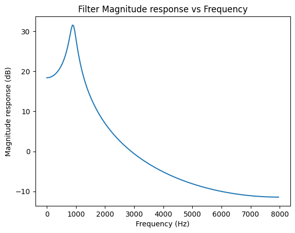

```python
#transfer function as a discrete linear time invariant system
system = signal.dlti([1.0,0.0,0.0], [1, -1.8041253513834825, 0.9244652503762558], dt=0.0000625)
#magnitude response vs frequency
freq, resp= signal.dlti.freqresp(system,n=200)
#scaling axes (Y axis in decibel and x axis using sampling frequency)
plt.plot(16000*freq/(2*math.pi),20*np.log10(np.abs(resp)))
#labelling graph
plt.xlabel('Frequency (Hz)')
plt.ylabel('Magnitude response (dB)')
plt.title('Filter Magnitude response vs Frequency')
```

Plotting filter impulse response:

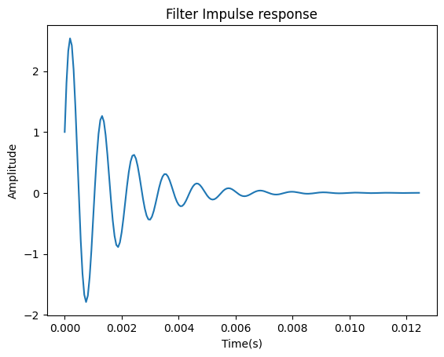

```python
#Impulse response vs time
t,y = signal.dimpulse(system,n=200)
plt.plot(t, y[0])
#labelling graph
plt.xlabel('Time(s)')
plt.ylabel('Amplitude')
plt.title('Filter Impulse response')
```

# Question 2

Generating input signal at 160 Hz, using a train of triangular pulses:

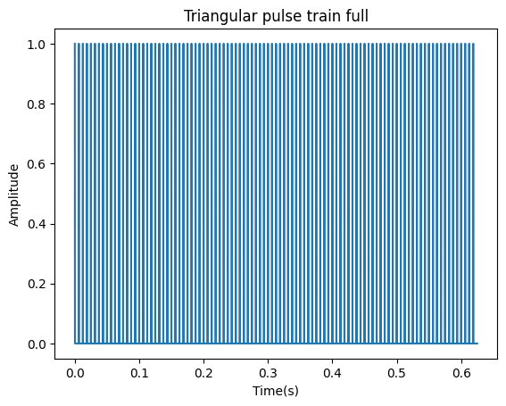

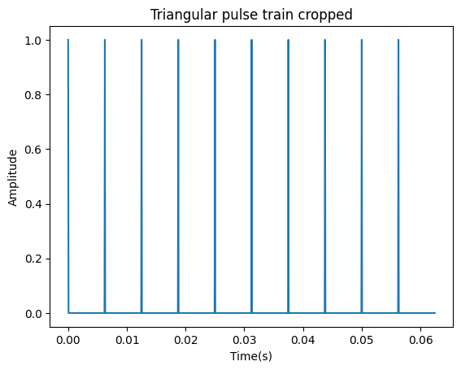

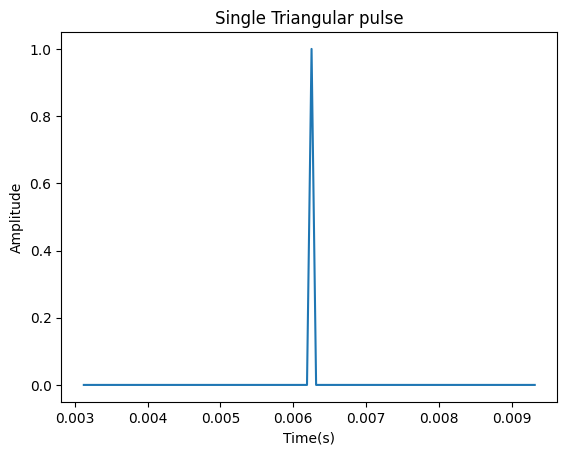

```python
#importing libraries
import scipy.signal as signal
from IPython.display import Audio, display

arr=[]
for i in range(100):
  arr.append(i*100)
#Generating a tringular pulse after every 100 samples for an array of 10000 samples, so when sampling rate is 16000 Hz, the signal frequency will be 160 Hz
imp = signal.unit_impulse(10000, arr)
#plotting on the time axis, for sampling rate 16000, there will be 10000 samples in 0.625 seconds
t=np.linspace(0,0.625,10000)
plt.plot(t, imp)
#labelling graph
plt.xlabel('Time(s)')
plt.ylabel('Amplitude')
plt.title('Triangular pulse train full')
plt.show()
plt.plot(t[:1000], imp[:1000])
plt.xlabel('Time(s)')
plt.ylabel('Amplitude')
plt.title('Triangular pulse train cropped')
plt.show()
plt.plot(t[50:150], imp[50:150])
plt.xlabel('Time(s)')
plt.ylabel('Amplitude')
plt.title('Single Triangular pulse')
plt.show()
```

Transfer function $H(z)= \frac{1}{1-1.8041z^{-1}+0.9245z^{-2}}$ = $\frac{Y}{X}$

so, y[n] = x[n] + 1.8041 y[n-1] - 0.9245 y[n-2]

is the difference equation of the LTI system

Using difference equation to calculate output of pulse train when passed through filter:

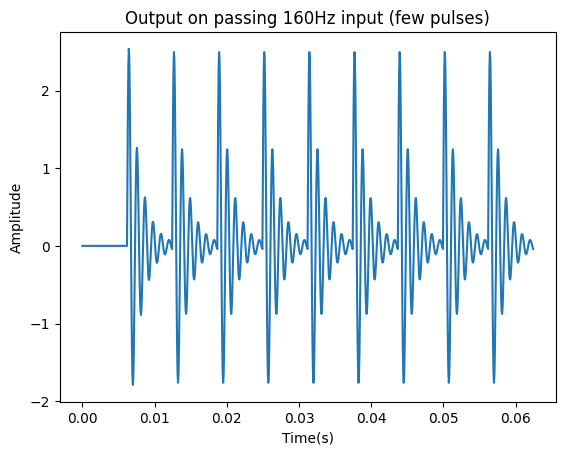

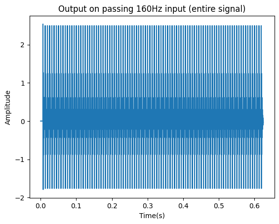

```python
#Loop for difference equation
out=np.zeros_like(imp)
for i in range(10000):
  if (i==0 or i==1):
    out[i]=0
  else:
    out[i]=(imp[i]+1.8041253513834825*out[i-1]-0.9244652503762558*out[i-2])

#plotting the output of the filter
t=np.linspace(0,0.625,10000)
plt.plot(t[:1000], out[:1000])
plt.xlabel('Time(s)')
plt.ylabel('Amplitude')
plt.title('Output on passing 160Hz input (few pulses)')
plt.show()
plt.plot(t, out)
plt.xlabel('Time(s)')
plt.ylabel('Amplitude')
plt.title('Output on passing 160Hz input (entire signal)')
plt.show()
```

Audio of the signal:

```python
#Conversion to audio
Audio(np.asfarray(out),rate=16000)
```

[interactive chart not shown]

This sounds more like an "ahh"

The sound quality is not good, but due to high bandwidth, the decay of the impulse response is more sharp, making it sound sharp. It seems electronic.

# Question 3

# Part A

Given:

$F_1$ (Formant) = 300 Hz

$B_1$ (Bandwidth) = 120 Hz

$F_s$ (Sampling Frequency) = 16000 Hz so $T_s (Sampling Period) = 0.0000625 s $

We know that $r=e^{-\pi B_i T_s}$ and $θ=2 \pi F_1 T_s $

where $r e^{\pm j θ}$ are the poles of the denominator of the transfer function

Transfer function $H(z)= \frac{1}{(1-r e^{-jθ}z^{-1})(1-r e^{+jθ}z^{-1})} = \frac{1}{1-2rcosθz^{-1}+r^{2}z^{-2}}$ = $\frac{1}{1-1.9399z^{-1}+0.9540z^{-2}}$

```python
#importing libraries
import math
from scipy import signal
import numpy as np
import matplotlib.pyplot as plt
from scipy.io.wavfile import write

#assigning values
f1=300.0
b1=120.0
fs=16000.0
ts=1.0/fs

#calculating coefficients of transfer function
r=pow(math.e,-1*math.pi*b1*ts)
theta=2*math.pi*f1*ts
print("r=",r)
print("theta=",theta)
print("coeff2=",2*r*math.cos(theta))
print("coeff3=",r**2)
```

```
r= 0.9767134703747672
theta= 0.11780972450961724
coeff2= 1.9398866778243222
coeff3= 0.9539692032115212
```

Plotting filter magnitude response |H(z)| in decibel:

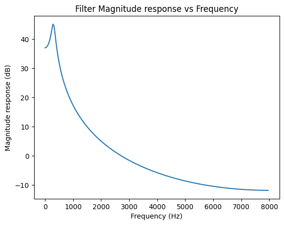

```python
#transfer function as a discrete linear time invariant system
system = signal.dlti([1.0,0.0,0.0], [1, -1.9398866778243222, 0.9539692032115212], dt=0.0000625)
#magnitude response vs frequency
freq, resp= signal.dlti.freqresp(system,n=200)
#scaling axes (Y axis in decibel and x axis using sampling frequency)
plt.plot(16000*freq/(2*math.pi),20*np.log10(np.abs(resp)))
#labelling graph
plt.xlabel('Frequency (Hz)')
plt.ylabel('Magnitude response (dB)')
plt.title('Filter Magnitude response vs Frequency')
```

Plotting filter impulse response:

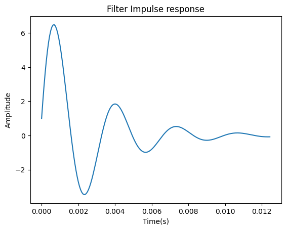

```python
#Impulse response vs time
t,y = signal.dimpulse(system,n=200)
plt.plot(t, y[0])
#labelling graph
plt.xlabel('Time(s)')
plt.ylabel('Amplitude')
plt.title('Filter Impulse response')
```

Generating input signal at 120 Hz, using a train of triangular pulses:

```python
#importing libraries
import scipy.signal as signal
from IPython.display import Audio, display

arr=[]
for i in range(60):
  arr.append(int(i*133.33))
#Generating a triangular pulse for 60 samples in an array of 8000 samples, so when sampling rate is 16000 Hz, the signal frequency will be 120 Hz
imp = signal.unit_impulse(8000, arr)
#plotting on the time axis, for sampling rate 16000, there will be 10000 samples in 0.625 seconds
t=np.linspace(0,0.5,8000)
plt.plot(t, imp)
#labelling graph
plt.xlabel('Time(s)')
plt.ylabel('Amplitude')
plt.title('Triangular pulse train full')
plt.show()
plt.plot(t[:1000], imp[:1000])
plt.xlabel('Time(s)')
plt.ylabel('Amplitude')
plt.title('Triangular pulse train cropped')
plt.show()
plt.plot(t[50:150], imp[50:150])
plt.xlabel('Time(s)')
plt.ylabel('Amplitude')
plt.title('Single Triangular pulse')
plt.show()
```

[output not shown]

Transfer function $H(z)= \frac{1}{1-1.9399z^{-1}+0.9540z^{-2}}$ = $\frac{Y}{X}$

so, y[n] = x[n] + 1.9399 y[n-1] - 0.9540 y[n-2]

is the difference equation of the LTI system

Using difference equation to calculate output of pulse train when passed through filter:

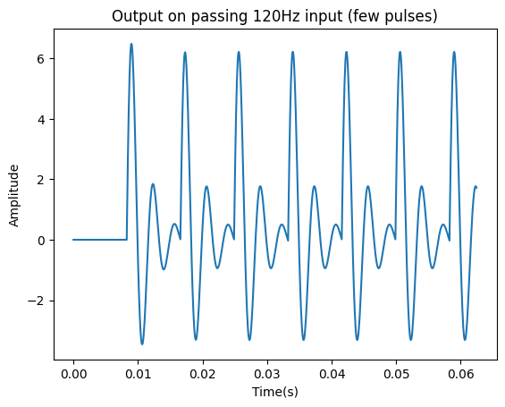

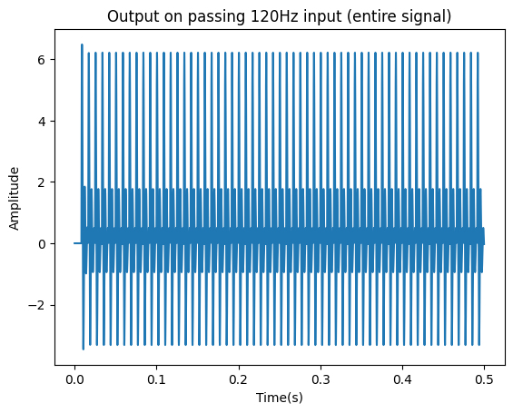

```python
#Loop for difference equation
out=np.zeros_like(imp)
for i in range(8000):
  if (i==0 or i==1):
    out[i]=0
  else:
    out[i]=(imp[i]+1.9398866778243222*out[i-1]-0.9539692032115212*out[i-2])

#plotting the output of the filter
t=np.linspace(0,0.5,8000)
plt.plot(t[:1000], out[:1000])
plt.xlabel('Time(s)')
plt.ylabel('Amplitude')
plt.title('Output on passing 120Hz input (few pulses)')
plt.show()
plt.plot(t, out)
plt.xlabel('Time(s)')
plt.ylabel('Amplitude')
plt.title('Output on passing 120Hz input (entire signal)')
plt.show()
```

Audio of the signal:

```python
#Conversion to audio
Audio(np.asfarray(out),rate=16000)
```

[interactive chart not shown]

This sounds more like an "uhh"

The sound quality is not good, but we can tell that the pitch has reduced as compared to the previous case and since the bandwidth is lower. the decay of the impulse response is more gradual, making it sound more muffled.

# Part B

Given:

$F_1$ (Formant) = 1100 Hz

$B_1$ (Bandwidth) = 200 Hz

$F_s$ (Sampling Frequency) = 16000 Hz so $T_s (Sampling Period) = 0.0000625 s $

We know that $r=e^{-\pi B_i T_s}$ and $θ=2 \pi F_1 T_s $

where $r e^{\pm j θ}$ are the poles of the denominator of the transfer function

Transfer function $H(z)= \frac{1}{(1-r e^{-jθ}z^{-1})(1-r e^{+jθ}z^{-1})} = \frac{1}{1-2rcosθz^{-1}+r^{2}z^{-2}}$ = $\frac{1}{1-1.7463z^{-1}+0.9245z^{-2}}$

```python
#importing libraries
import math
from scipy import signal
import numpy as np
import matplotlib.pyplot as plt
from scipy.io.wavfile import write

#assigning values
f1=1100.0
b1=200.0
fs=16000.0
ts=1.0/fs

#calculating coefficients of transfer function
r=pow(math.e,-1*math.pi*b1*ts)
theta=2*math.pi*f1*ts
print("r=",r)
print("theta=",theta)
print("coeff2=",2*r*math.cos(theta))
print("coeff3=",r**2)
```

```
r= 0.9614911598014075
theta= 0.43196898986859655
coeff2= 1.7463432669336172
coeff3= 0.9244652503762558
```

Plotting filter magnitude response |H(z)| in decibel:

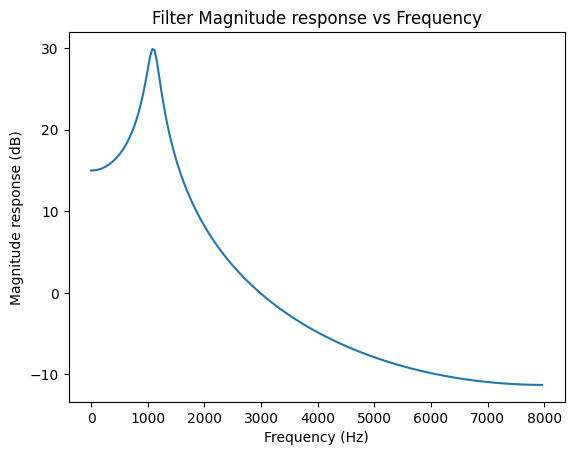

```python
#transfer function as a discrete linear time invariant system
system = signal.dlti([1.0,0.0,0.0], [1, -1.7463432669336172, 0.9244652503762558], dt=0.0000625)
#magnitude response vs frequency
freq, resp= signal.dlti.freqresp(system,n=200)
#scaling axes (Y axis in decibel and x axis using sampling frequency)
plt.plot(16000*freq/(2*math.pi),20*np.log10(np.abs(resp)))
#labelling graph
plt.xlabel('Frequency (Hz)')
plt.ylabel('Magnitude response (dB)')
plt.title('Filter Magnitude response vs Frequency')
```

Plotting filter impulse response:

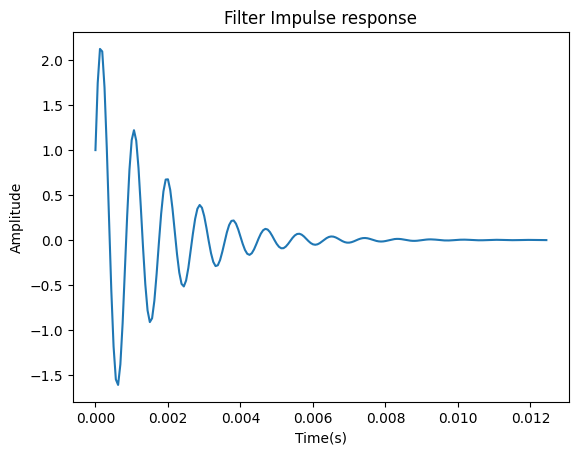

```python
#Impulse response vs time
t,y = signal.dimpulse(system,n=200)
plt.plot(t, y[0])
#labelling graph
plt.xlabel('Time(s)')
plt.ylabel('Amplitude')
plt.title('Filter Impulse response')
```

Generating input signal at 120 Hz, using a train of triangular pulses:

```python
#importing libraries
import scipy.signal as signal
from IPython.display import Audio, display

arr=[]
for i in range(60):
  arr.append(int(i*133.33))
#Generating a triangular pulse for 60 samples in an array of 8000 samples, so when sampling rate is 16000 Hz, the signal frequency will be 120 Hz
imp = signal.unit_impulse(8000, arr)
#plotting on the time axis, for sampling rate 16000, there will be 10000 samples in 0.625 seconds
t=np.linspace(0,0.5,8000)
plt.plot(t, imp)
#labelling graph
plt.xlabel('Time(s)')
plt.ylabel('Amplitude')
plt.title('Triangular pulse train full')
plt.show()
plt.plot(t[:1000], imp[:1000])
plt.xlabel('Time(s)')
plt.ylabel('Amplitude')
plt.title('Triangular pulse train cropped')
plt.show()
plt.plot(t[50:150], imp[50:150])
plt.xlabel('Time(s)')
plt.ylabel('Amplitude')
plt.title('Single Triangular pulse')
plt.show()
```

[output not shown]

Transfer function $H(z)= \frac{1}{1-1.7463z^{-1}+0.9245z^{-2}}$ = $\frac{Y}{X}$

so, y[n] = x[n] + 1.7463 y[n-1] - 0.9245 y[n-2]

is the difference equation of the LTI system

Using difference equation to calculate output of pulse train when passed through filter:

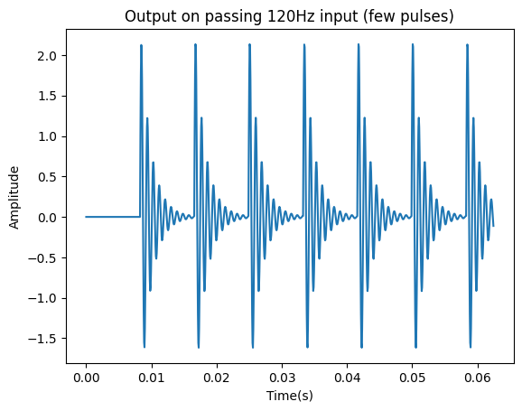

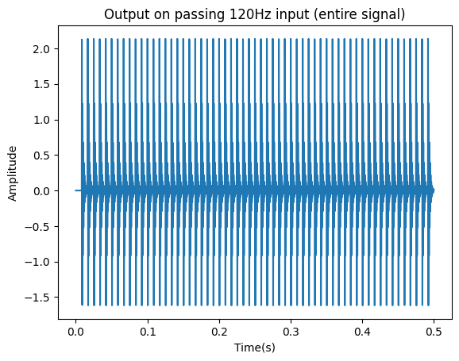

```python
#Loop for difference equation
out=np.zeros_like(imp)
for i in range(8000):
  if (i==0 or i==1):
    out[i]=0
  else:
    out[i]=(imp[i]+1.7463432669336172*out[i-1]-0.9244652503762558*out[i-2])

#plotting the output of the filter
t=np.linspace(0,0.5,8000)
plt.plot(t[:1000], out[:1000])
plt.xlabel('Time(s)')
plt.ylabel('Amplitude')
plt.title('Output on passing 120Hz input (few pulses)')
plt.show()
plt.plot(t, out)
plt.xlabel('Time(s)')
plt.ylabel('Amplitude')
plt.title('Output on passing 120Hz input (entire signal)')
plt.show()
```

Audio of the signal:

```python
#Conversion to audio
Audio(np.asfarray(out),rate=16000)
```

[interactive chart not shown]

This sounds more like an "ohh"

The sound quality is not good, but we can tell that the pitch is similar to the previous case and since the bandwidth is higher, the decay of the impulse response is sharper, making it sound more sharp.

# Part c

Given:

$F_1$ (Formant) = 300 Hz

$B_1$ (Bandwidth) = 120 Hz

$F_s$ (Sampling Frequency) = 16000 Hz so $T_s (Sampling Period) = 0.0000625 s $

We know that $r=e^{-\pi B_i T_s}$ and $θ=2 \pi F_1 T_s $

where $r e^{\pm j θ}$ are the poles of the denominator of the transfer function

Transfer function $H(z)= \frac{1}{(1-r e^{-jθ}z^{-1})(1-r e^{+jθ}z^{-1})} = \frac{1}{1-2rcosθz^{-1}+r^{2}z^{-2}}$ = $\frac{1}{1-1.9399z^{-1}+0.9539z^{-2}}$

```python
#importing libraries
import math
from scipy import signal
import numpy as np
import matplotlib.pyplot as plt
from scipy.io.wavfile import write

#assigning values
f1=300.0
b1=120.0
fs=16000.0
ts=1.0/fs

#calculating coefficients of transfer function
r=pow(math.e,-1*math.pi*b1*ts)
theta=2*math.pi*f1*ts
print("r=",r)
print("theta=",theta)
print("coeff2=",2*r*math.cos(theta))
print("coeff3=",r**2)
```

```
r= 0.9767134703747672
theta= 0.11780972450961724
coeff2= 1.9398866778243222
coeff3= 0.9539692032115212
```

Plotting filter magnitude response |H(z)| in decibel:

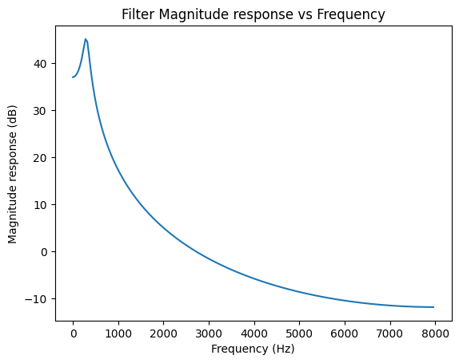

```python
#transfer function as a discrete linear time invariant system
system = signal.dlti([1.0,0.0,0.0], [1, -1.9398866778243222, 0.9539692032115212], dt=0.0000625)
#magnitude response vs frequency
freq, resp= signal.dlti.freqresp(system,n=200)
#scaling axes (Y axis in decibel and x axis using sampling frequency)
plt.plot(16000*freq/(2*math.pi),20*np.log10(np.abs(resp)))
#labelling graph
plt.xlabel('Frequency (Hz)')
plt.ylabel('Magnitude response (dB)')
plt.title('Filter Magnitude response vs Frequency')
```

Plotting filter impulse response:

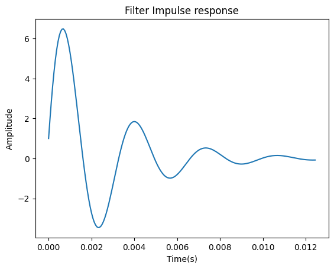

```python
#Impulse response vs time
t,y = signal.dimpulse(system,n=200)
plt.plot(t, y[0])
#labelling graph
plt.xlabel('Time(s)')
plt.ylabel('Amplitude')
plt.title('Filter Impulse response')
```

Generating input signal at 180 Hz, using a train of triangular pulses:

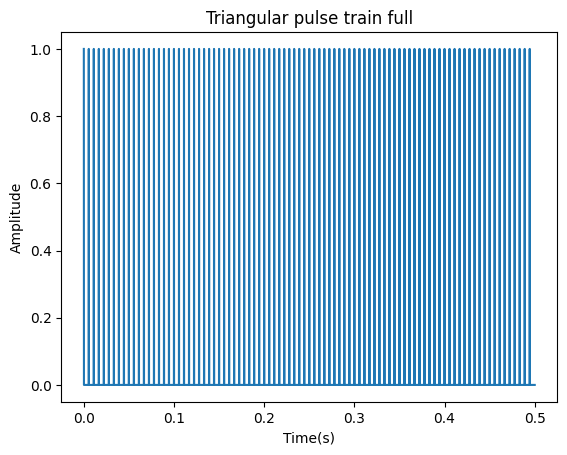

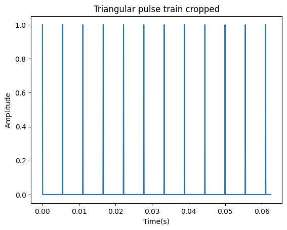

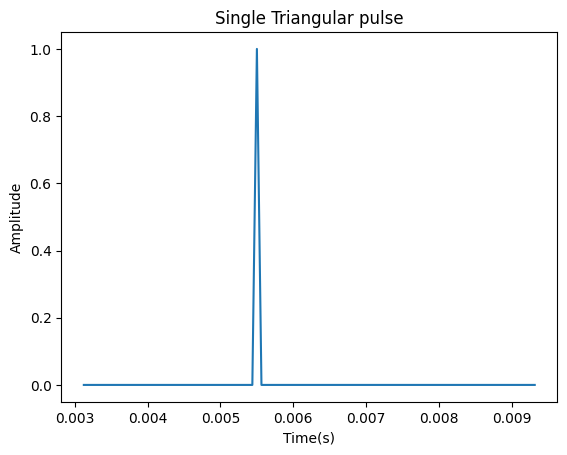

```python
#importing libraries
import scipy.signal as signal
from IPython.display import Audio, display

arr=[]
for i in range(90):
  arr.append(int(i*88.88))
#Generating a triangular pulse for 90 samples in an array of 8000 samples, so when sampling rate is 16000 Hz, the signal frequency will be 120 Hz
imp = signal.unit_impulse(8000, arr)
#plotting on the time axis, for sampling rate 16000, there will be 10000 samples in 0.625 seconds
t=np.linspace(0,0.5,8000)
plt.plot(t, imp)
#labelling graph
plt.xlabel('Time(s)')
plt.ylabel('Amplitude')
plt.title('Triangular pulse train full')
plt.show()
plt.plot(t[:1000], imp[:1000])
plt.xlabel('Time(s)')
plt.ylabel('Amplitude')
plt.title('Triangular pulse train cropped')
plt.show()
plt.plot(t[50:150], imp[50:150])
plt.xlabel('Time(s)')
plt.ylabel('Amplitude')
plt.title('Single Triangular pulse')
plt.show()
```

Transfer function $H(z)= \frac{1}{1-1.9399z^{-1}+0.9539z^{-2}}$ = $\frac{Y}{X}$

Using difference equation to calculate output of pulse train when passed through filter:

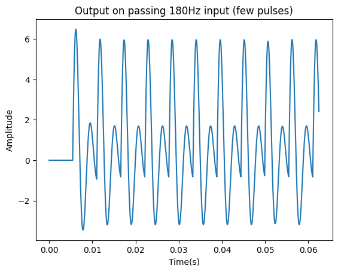

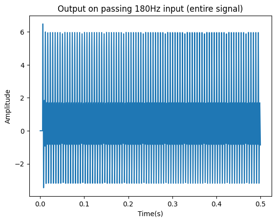

```python
#Loop for difference equation
out=np.zeros_like(imp)
for i in range(8000):
  if (i==0 or i==1):
    out[i]=0
  else:
    out[i]=(imp[i]+1.9398866778243222*out[i-1]-0.9539692032115212*out[i-2])

#plotting the output of the filter
t=np.linspace(0,0.5,8000)
plt.plot(t[:1000], out[:1000])
plt.xlabel('Time(s)')
plt.ylabel('Amplitude')
plt.title('Output on passing 180Hz input (few pulses)')
plt.show()
plt.plot(t, out)
plt.xlabel('Time(s)')
plt.ylabel('Amplitude')
plt.title('Output on passing 180Hz input (entire signal)')
plt.show()
```

Audio of the signal:

```python
#Conversion to audio
Audio(np.asfarray(out),rate=16000)
```

[interactive chart not shown]

This sounds more like a high pitched "uhh"

The sound quality is not good, but we can tell that the pitch has increased as compared to the previous case and since the bandwidth is lower, the decay of the impulse response is more gradual, making it sound more muffled.

**Conclusion:**

**We can see that higher bandwidth causes a sharper electronic sounding sound.**

**Higher impulse train frequency causes higher pitch. Change in formant frequancy causes change in the vowel it sounds like (actual sound changes)**

# Question 4

# Generating input signals

Generating input signal at 120 Hz, using a train of triangular pulses:

```python
#importing libraries
import scipy.signal as signal
from IPython.display import Audio, display

arr=[]
for i in range(60):
  arr.append(int(i*133.33))
#Generating a triangular pulse for 60 samples in an array of 8000 samples, so when sampling rate is 16000 Hz, the signal frequency will be 120 Hz
imp120 = signal.unit_impulse(8000, arr)
#plotting on the time axis, for sampling rate 16000, there will be 10000 samples in 0.625 seconds
t=np.linspace(0,0.5,8000)
plt.plot(t, imp120)
#labelling graph
plt.xlabel('Time(s)')
plt.ylabel('Amplitude')
plt.title('Triangular pulse train full')
plt.show()
plt.plot(t[:1000], imp120[:1000])
plt.xlabel('Time(s)')
plt.ylabel('Amplitude')
plt.title('Triangular pulse train cropped')
plt.show()
plt.plot(t[50:150], imp120[50:150])
plt.xlabel('Time(s)')
plt.ylabel('Amplitude')
plt.title('Single Triangular pulse')
plt.show()
```

[output not shown]

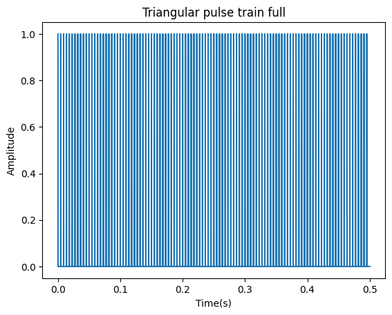

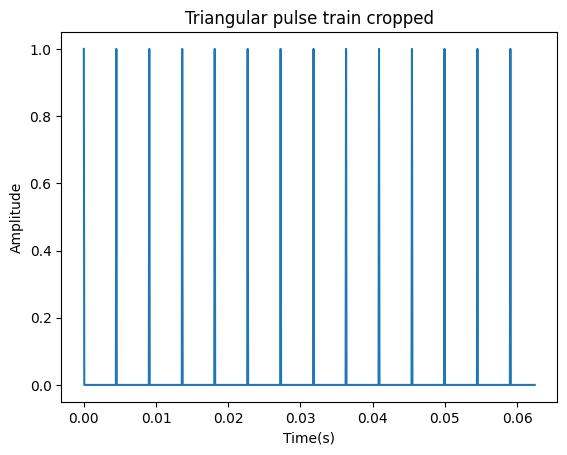

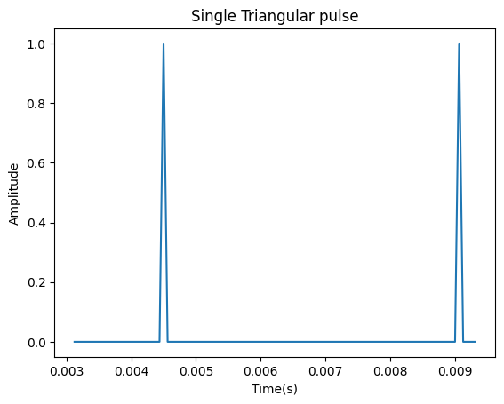

```python
#importing libraries
import scipy.signal as signal
from IPython.display import Audio, display

arr=[]
for i in range(110):
  arr.append(int(i*72.72))
#Generating a triangular pulse for 110 samples in an array of 8000 samples, so when sampling rate is 16000 Hz, the signal frequency will be 120 Hz
imp220 = signal.unit_impulse(8000, arr)
#plotting on the time axis, for sampling rate 16000, there will be 10000 samples in 0.625 seconds
t=np.linspace(0,0.5,8000)
plt.plot(t, imp220)
#labelling graph
plt.xlabel('Time(s)')
plt.ylabel('Amplitude')
plt.title('Triangular pulse train full')
plt.show()
plt.plot(t[:1000], imp220[:1000])
plt.xlabel('Time(s)')
plt.ylabel('Amplitude')
plt.title('Triangular pulse train cropped')
plt.show()
plt.plot(t[50:150], imp220[50:150])
plt.xlabel('Time(s)')
plt.ylabel('Amplitude')
plt.title('Single Triangular pulse')
plt.show()
```

$B_1$ (Bandwidth) = 100 Hz

$F_s$ (Sampling Frequency) = 16000 Hz so $T_s (Sampling Period) = 0.0000625 s $

We know that $r=e^{-\pi B_i T_s}$ and $θ=2 \pi F_x T_s $

where $r e^{\pm j θ}$ are the poles of the denominator of the transfer function

For 3 formants, we have 6 poles

We construct the transfer function and then make the difference equation

# Vowel /a/

```python
#importing libraries
import scipy
import math
from scipy import signal
import numpy as np
import matplotlib.pyplot as plt
from scipy.io.wavfile import write

#assigning values
f1=730.0
f2=1090.0
f3=2440.0
b1=100.0
fs=16000.0
ts=1.0/fs

#calculating coefficients of transfer function
r=pow(math.e,-1*math.pi*b1*ts)
theta1=2*math.pi*f1*ts
theta2=2*math.pi*f2*ts
theta3=2*math.pi*f3*ts
z=[0,0,0,0,0,0]
p=[r*pow(math.e,1j*theta1), r*pow(math.e,-1*1j*theta1), r*pow(math.e,1j*theta2),r*pow(math.e,-1*1j*theta2),r*pow(math.e,1j*theta3),r*pow(math.e,-1*1j*theta3) ]
a,b=scipy.signal.zpk2tf(z, p, 1)
print(a)
print(b)
```

```
[1. 0. 0. 0. 0. 0. 0.]
[  1.          -4.79291373  10.37380055 -13.00129892   9.97431752
  -4.4308822    0.88886517]
```

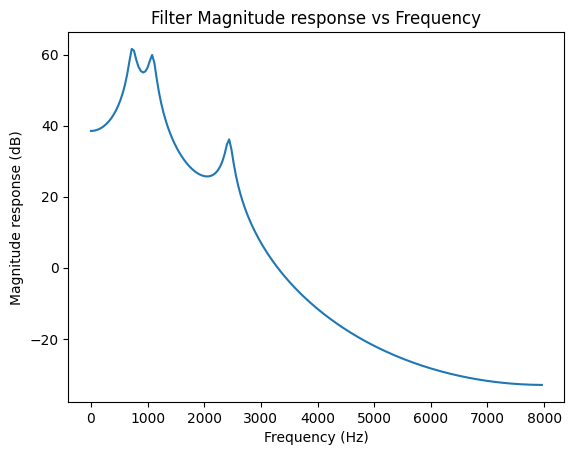

```python
#transfer function as a discrete linear time invariant system
system = signal.dlti(a, b, dt=0.0000625)
#magnitude response vs frequency
freq, resp= signal.dlti.freqresp(system,n=200)
#scaling axes (Y axis in decibel and x axis using sampling frequency)
plt.plot(16000*freq/(2*math.pi),20*np.log10(np.abs(resp)))
#labelling graph
plt.xlabel('Frequency (Hz)')
plt.ylabel('Magnitude response (dB)')
plt.title('Filter Magnitude response vs Frequency')
```

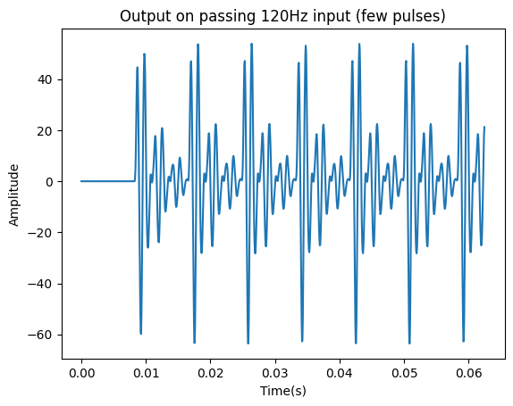

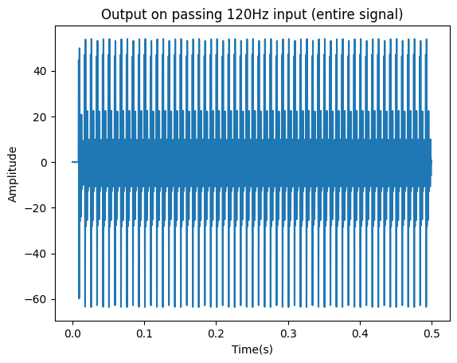

```python
out=np.zeros_like(imp120)
for i in range(8000):
  if (i==0 or i==1 or i==2 or i==3 or i==4 or i==5):
    out[i]=0
  else:
    out[i]=(imp120[i]-b[1]*out[i-1]-b[2]*out[i-2]-b[3]*out[i-3]-b[4]*out[i-4]-b[5]*out[i-5]-b[6]*out[i-6])

    #plotting the output of the filter
t=np.linspace(0,0.5,8000)
plt.plot(t[:1000], out[:1000])
plt.xlabel('Time(s)')
plt.ylabel('Amplitude')
plt.title('Output on passing 120Hz input (few pulses)')
plt.show()
plt.plot(t, out)
plt.xlabel('Time(s)')
plt.ylabel('Amplitude')
plt.title('Output on passing 120Hz input (entire signal)')
plt.show()
```

```python
#Conversion to audio
Audio(np.asfarray(out),rate=16000)
```

[interactive chart not shown]

Sounds like a low pitched /a/

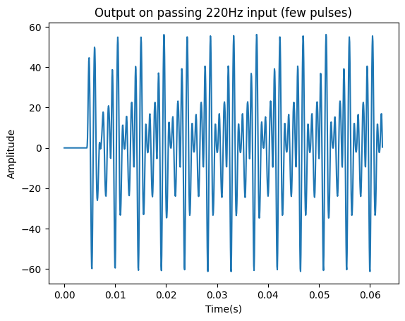

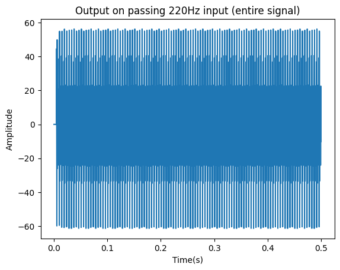

```python
out=np.zeros_like(imp120)
for i in range(8000):
  if (i==0 or i==1 or i==2 or i==3 or i==4 or i==5):
    out[i]=0
  else:
    out[i]=(imp220[i]-b[1]*out[i-1]-b[2]*out[i-2]-b[3]*out[i-3]-b[4]*out[i-4]-b[5]*out[i-5]-b[6]*out[i-6])

    #plotting the output of the filter
t=np.linspace(0,0.5,8000)
plt.plot(t[:1000], out[:1000])
plt.xlabel('Time(s)')
plt.ylabel('Amplitude')
plt.title('Output on passing 220Hz input (few pulses)')
plt.show()
plt.plot(t, out)
plt.xlabel('Time(s)')
plt.ylabel('Amplitude')
plt.title('Output on passing 220Hz input (entire signal)')
plt.show()
```

```python
#Conversion to audio
Audio(np.asfarray(out),rate=16000)
```

[interactive chart not shown]

Sounds like a high pitched /a/